# Data Visualization: ggplot2 tutorial using gapminder dataset

#### Customizing the plot

The last plot, on the log scale has ugly labels, let’s try to adjust the scale:

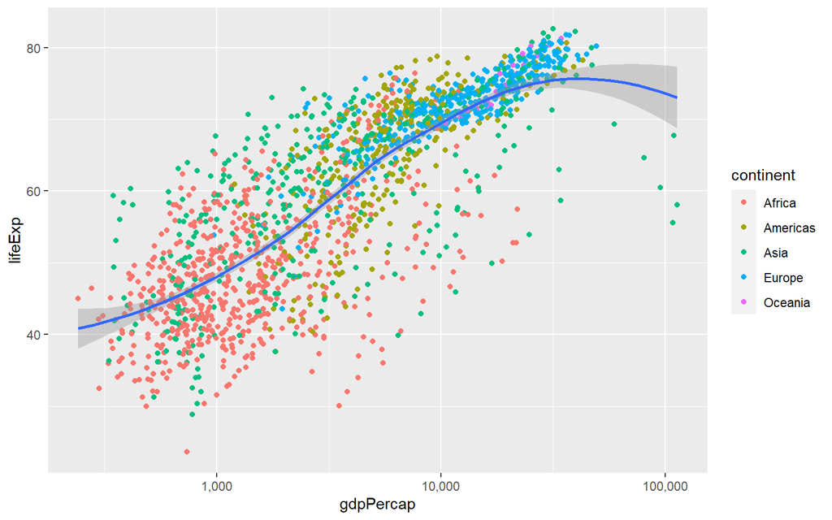

```r
plt + geom_point(aes(color=continent)) +
  geom_smooth(method="loess") +
  scale_x_log10(labels=scales::comma)    #adjusting scale
```

Moving the legends inside the plot:

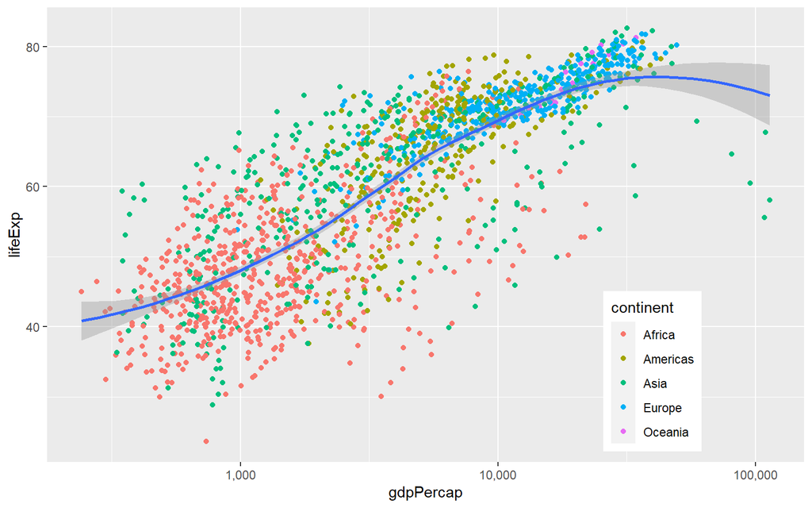

```r
plt + geom_point(aes(color=continent)) +
  geom_smooth(method="loess") +
  scale_x_log10(labels=scales::comma) +
  theme(legend.position = c(0.8, 0.2)) # putting the legend inside the plot
```

Changing the theme:

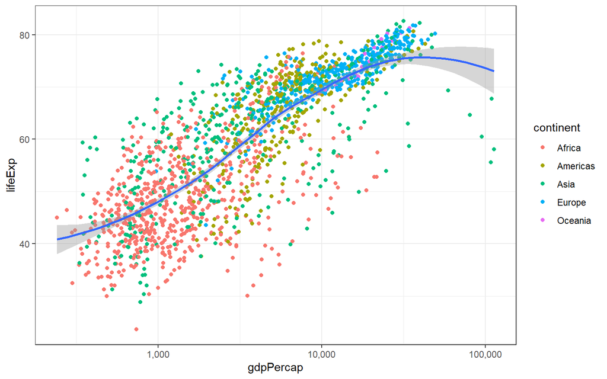

```r
plt + geom_point(aes(color=continent)) +
  geom_smooth(method="loess") +
  scale_x_log10(labels=scales::comma) +
  theme_bw()   #changing the theme of the plot
```

Replacing the single loess smoothed curve with a separate regression line for each continent:

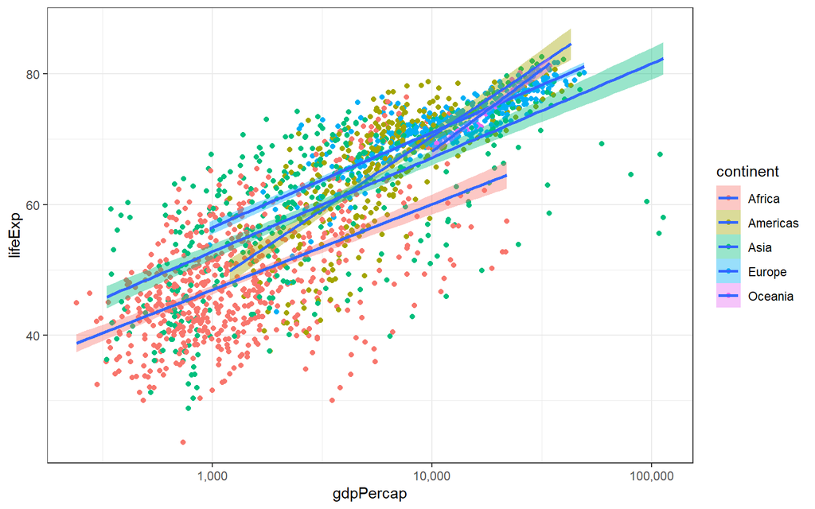

```r
plt + geom_point(aes(color=continent)) +
  geom_smooth(aes(fill= continent) , method="lm") +
  scale_x_log10(labels=scales::comma) +
  theme_bw()     #smoothing by a regression line for each continent
```

Making a “bubble” plot, mapping the `size` of each point to population `(pop)`

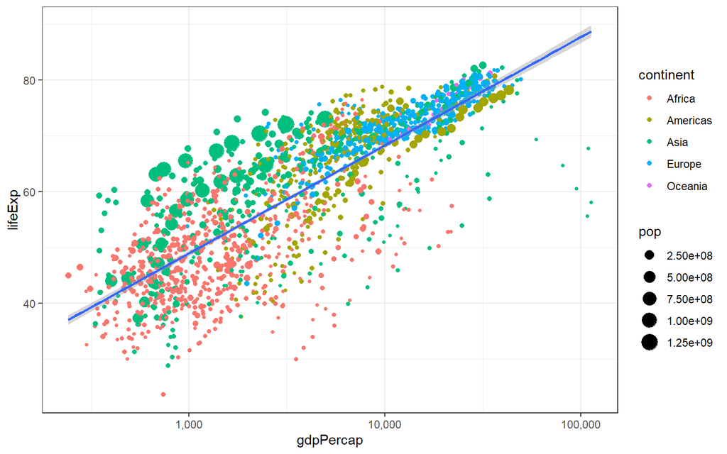

```r
plt + geom_point(aes(size = pop, color=continent)) +  #making a bubble plot by mapping the size of each point to population
  geom_smooth(method="lm") +
  scale_x_log10(labels=scales::comma) +
  theme_bw()
```

Changing color shades:

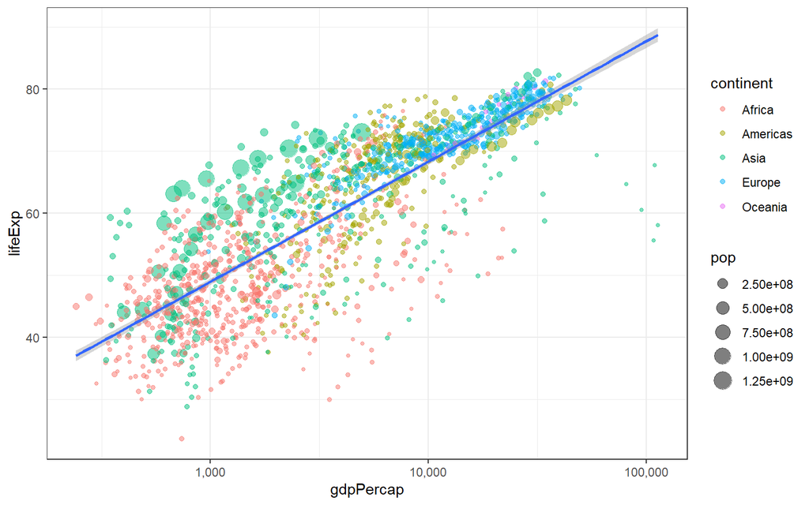

```r
plt + geom_point(aes(size = pop, color=continent), alpha = 0.5) +  #changing colors shade
  geom_smooth(method="lm") +
  scale_x_log10(labels=scales::comma) +
  theme_bw()
```

Let’s explore life expectancy by continent for a giving year. To do that, we will need to filter our data.

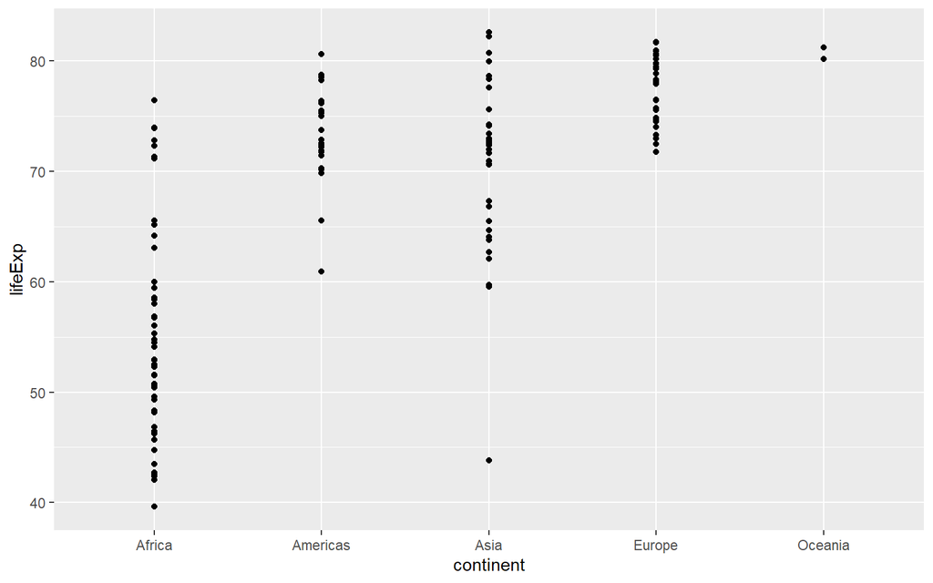

```r
gm_2007 <- subset(gapminder, year==2007) #filtering data by picking those of 2007
ggplot(gm_2007, aes(y=lifeExp, x=continent)) + geom_point()
```

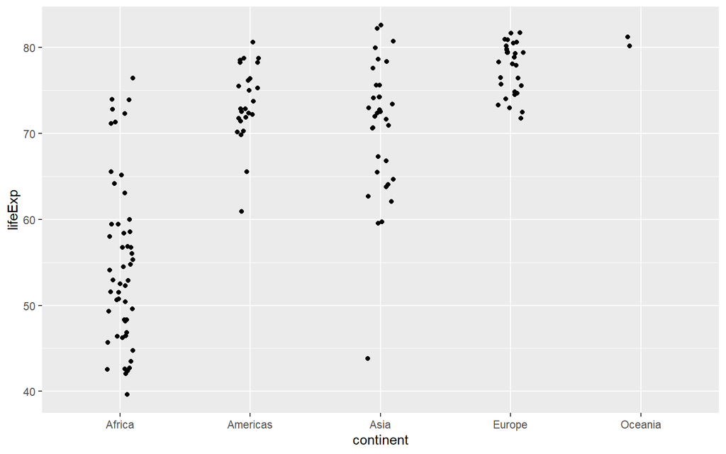

```r
ggplot(gm_2007, aes(y=lifeExp, x=continent)) +
  geom_point(position=position_jitter(width=0.1, height=0)) #changing scale by jittering
```

## Advanced customized and fancy plot

#### Bubble plot

Explorinf gdp versus life expectancy in 2007 with highlighting the larger countries filter our data.

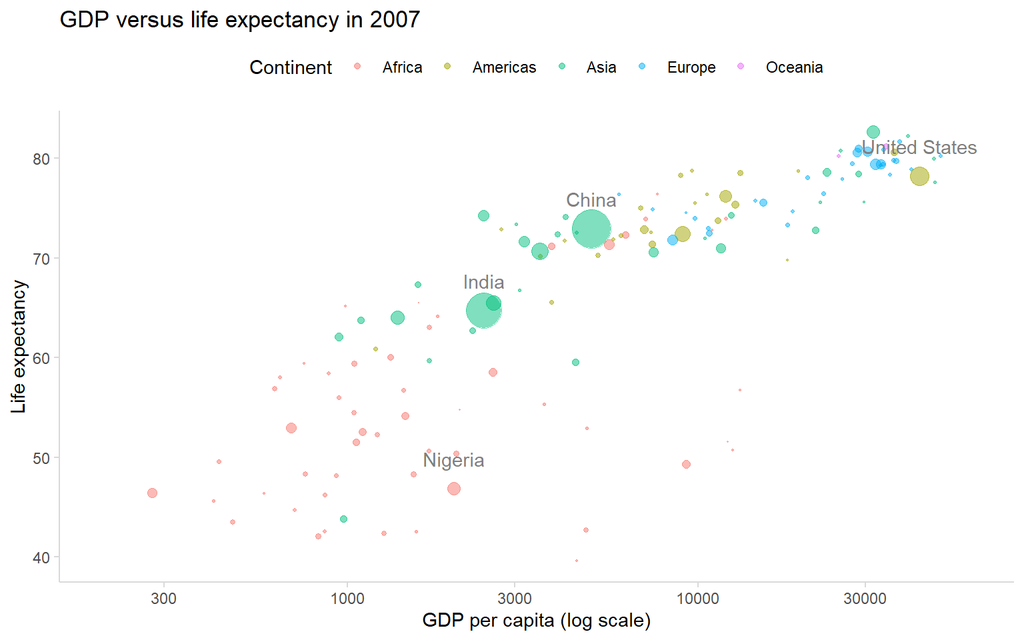

```r
ggplot(gm_2007) +
  geom_point(aes(x = gdpPercap, y = lifeExp, color = continent, size = pop),# add scatter points
             alpha = 0.5) +
  geom_text(aes(x = gdpPercap, y = lifeExp + 3, label = country), # add some text annotations for the very large countries
            color = "grey50",
            data = filter(gm_2007, pop > 1000000000 | country %in% c("Nigeria", "United States"))) +
  scale_x_log10(limits = c(200, 60000)) + # clean the axes names and breaks
  labs(title = "GDP versus life expectancy in 2007", # change labels
       x = "GDP per capita (log scale)",
       y = "Life expectancy",
       size = "Popoulation",
       color = "Continent") +
  scale_size(range = c(0.1, 10), # change the size scale
             guide = "none") + # remove size legend
  theme_classic() +   # add a nicer theme
  theme(legend.position = "top",  # place legend at top and grey axis lines
        axis.line = element_line(color = "grey85"),
        axis.ticks = element_line(color = "grey85"))
```